# Lower Michigan Mathematics Competition

April 2, 2022

### The Competition

The Lower Michigan Mathematics Competition is an annual event for university students from all around Michigan. Teams of 2-3 students will have 3 hours to create written solutions for ten problems. All work is to be done without the use of calculators, computers, or any other electronic devices. Solutions will be scored for correctness, completeness, style, and elegance.

### Registration

- Please register using [**EventBrite**](https://www.eventbrite.com/e/lower-michigan-mathematics-competition-tickets-297095299037)
- **Cost:** $20 per team (2-3 members per team)

### Logisitics

- **Date:** Saturday, April 2
- **Time:** 12:00 - 12:15 registration; 12:30 - 3:30 competition
  - Registration will be in the DeVries Hall Atrium. After checking in, teams can locate their competition rooms and then assemble in SB 110 at 12:20 for last-minute instructions and to receive their test packets.

    You are getting close if you see this sculpture (visible from the main road). Walk past it to get to the entrance.

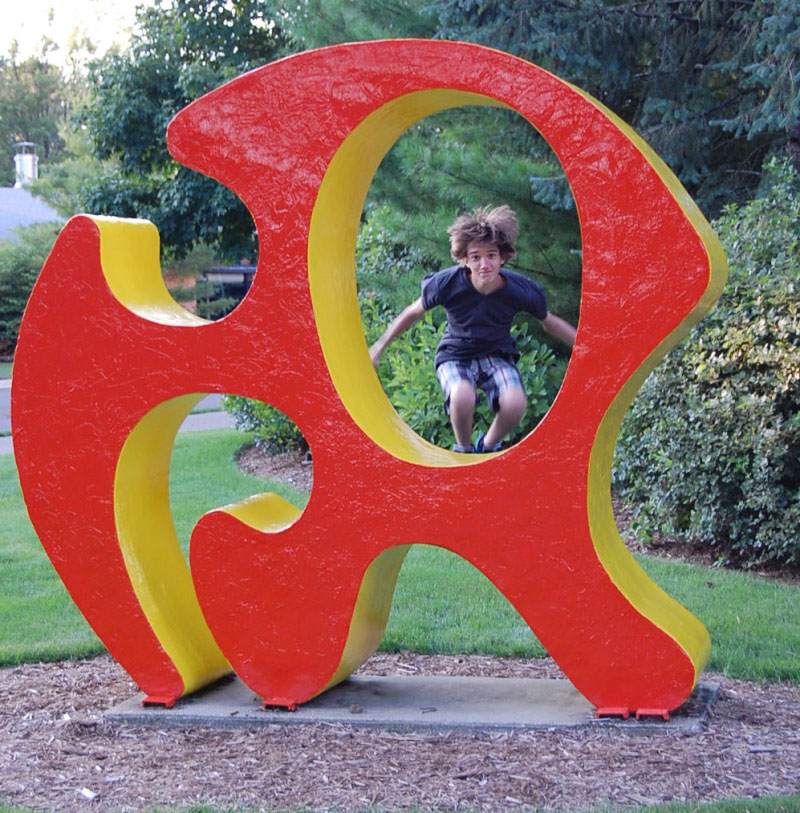

  - Upon completion of the competition, exams can be returned to SB 110. Those who wish to stay for a problem debriefing where students can present solutions are invited to do so.
- **Location:** Calvin University Science Complex ([Science Building](https://calvin.edu/directory/places/science-building), [North Hall](https://calvin.edu/directory/places/north-hall), and [DeVries Hall](https://calvin.edu/directory/places/devries-hall) are three adjoining buildings making up the Science Complex.)
- **Parking:** Parking is free. You may park in any lot along the west edge of campus. Lots 4 and 5 are the closest to the Science Building and North Hall.
- [**Campus Map**](https://calvin.edu/map/?place=north-hall)
- **Food.**
  - We are not providing a meal this year due to COVID-related uncertainties
  - We will provide some light snacks that teams may bring with them into the competition rooms.
  - On-campus food options are limited on Saturdays, but there are a number of [restaurants near campus](https://www.google.com/maps/search/restaurant+near+cavlin+university/@42.9214762,-85.5904898,15z), especially south of campus along 28th Street (Highway 11 on some maps, but no locals call it that).
  - Feel free to bring take-out food, sack lunches, etc. with you to the competition. Just be sure to leave the room as you found it (or better) at the end of the competition.
- **Masks** are *not* currently required on Calvin’s campus. If this should change, we will update here and also make masks available for anyone who does not bring their own. Of course, individuals are welcome to choose to wear a mask at any time.